# W15：線性迴歸——從相關到預測

心理教育統計 2026

授課教師：陳紹慶 | e-mail: csc2009@mail.tcu.edu.tw

2026/06/08

# 總結提示

- 個人累進學習成果報告，已載入累進成績結算及還可達成的目標。
- 本日(W15)上課前可努力的部分: W14, W15 LAB, W17 Final LAB
- W16 總複習無網路直播，上課內容有模擬試題即時演練及討論。

# 本週學習目標

**理解概念**：

1. 理解迴歸方程式 $Y = a + bX$ 的意義
2. 掌握迴歸係數 ($b$) 與截距 ($a$) 的解讀
3. 學會殘差的三項適用條件診斷（線性、常態性、變異同質性）
4. 理解迴歸係數的推論統計與標準化係數 $\beta$

**軟體操作**：

1. jamovi 執行 Linear Regression
2. 儲存預測值與殘差（Predicted values、Residuals）
3. 進行三項適用條件診斷（線性、常態性、變異同質性）
4. 讀取係數推論（t / p / 95% CI）與標準化係數 $\beta$

## 對應教材

- 《用 jamovi 上手統計學》[第 12 章：線性迴歸](https://scgeeker.github.io/lsj-book-zh_tw/12-Correlation-and-linear-regression.html#sec-what-is-linear-model)

**簡報示範資料**：

- parenthood（同 W14）：Dan爸的睡眠時數 vs 暴躁程度

**操作示範資料**： - “Study2_copy.xls”, [前置處理操作錄影](https://www.youtube.com/live/_UPqXWh1-Bs?si=12PvmLH83MUL_8Q2&t=5119)

**作業資料**：個人化 `W15_Regression_[學號].csv`

# Part 1：從相關到預測🧠

## 相關係數的統計資訊

**相關係數 $r$**：

- 描述兩個變項之間**線性關係的強度與方向**
- $r = -0.903$（parenthood 資料）

**但相關無法回答**：

- 如果 Dan爸 **多睡一小時**，暴躁指數會降低多少？
- 如果知道睡眠時數，能不能**預測**暴躁指數？

> 相關 → 描述關聯；迴歸 → **做出預測**

## 散佈圖 + 迴歸線

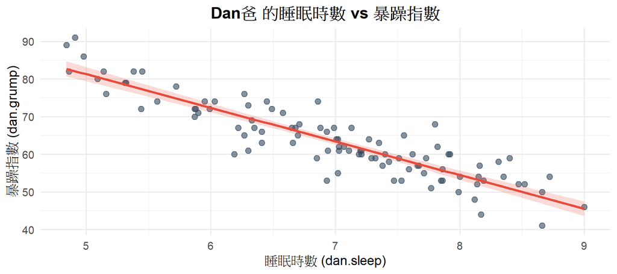

> 這條紅線就是**迴歸線**——最能代表資料趨勢的直線

## 最小平方法

**目標**：找出讓所有依變項(Y)資料到這條線的**垂直距離（殘差）的平方和最小**的一條直線。

$$\text{Residual} = (Y_i -
\hat{Y}_i)$$

$$\text{SSE} = \sum_{i=1}^{N} (Y_i -
\hat{Y}_i)^2 \rightarrow \text{最小化}$$

## 符合最小平方法的迴歸線

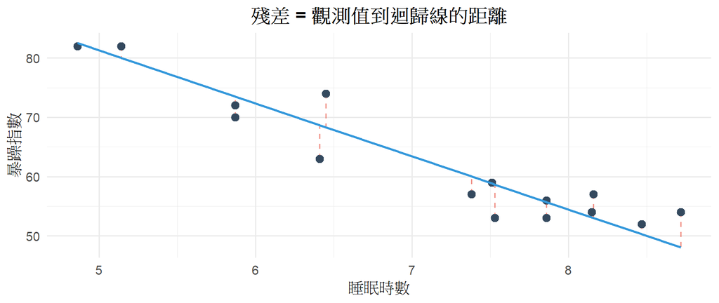

> 紅色虛線 = 殘差（越短越好）

# Part 2：迴歸方程式🧠

## $Y = a + bX$

$$\hat{Y} = a + b \times X$$

| 符號 | 名稱 | 意義 |
| --- | --- | --- |
| $\hat{Y}$ | 預測值 | 根據 X 預測出的 Y 值 |
| $a$ | 截距 (intercept) | 當 $X = 0$ 時，$\hat{Y}$ 的值 |
| $b$ | 迴歸係數 (regression coefficient) | $X$ 每增加 1 單位，$\hat{Y}$ 的變化量（即迴歸線斜率） |

## parenthood 的迴歸結果

$$\text{dan.grump} = 125.96 + (-8.94)
\times \text{dan.sleep}$$

**截距** $a = 125.96$：

- 如果 Dan爸 完全不睡覺（dan.sleep = 0），預測暴躁指數為 125.96
- ⚠ 外推解讀需謹慎（僅限測量範圍內可預測）

**迴歸係數** $b = -8.94$：

- 每多睡**一小時**，暴躁指數預測下降 8.94 點
- 負號 = 負向關係（睡越多 → 越不暴躁）

## 迴歸係數的意義

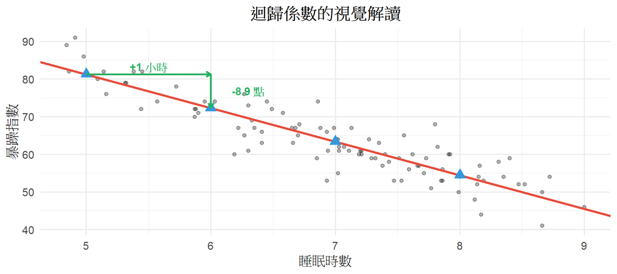

> X 增加 1 → Y 變化 b → 這就是「預測」

# Part 3：$R^2$ 與模型好壞🧠👨‍💻

## 迴歸模型能解釋多少變異？

$$R^2 = 1 -
\frac{SS_{\text{residual}}}{SS_{\text{total}}}$$

| 成分 | 公式 | 意義 |
| --- | --- | --- |
| $SS_{\text{total}}$ | $\sum(Y_i - \bar{Y})^2$ | 資料的**總變異** |
| $SS_{\text{residual}}$ | $\sum(Y_i - \hat{Y}_i)^2$ | 模型**無法解釋**的變異 |
| $SS_{\text{model}}$ | $SS_{\text{total}} - SS_{\text{residual}}$ | 模型**能解釋**的變異 |

## parenthood 的 $R^2$

$$R^2 = 0.8161$$

**解讀**：睡眠時數可以解釋暴躁指數 **81.6%** 的變異

## $R^2$ 的直覺

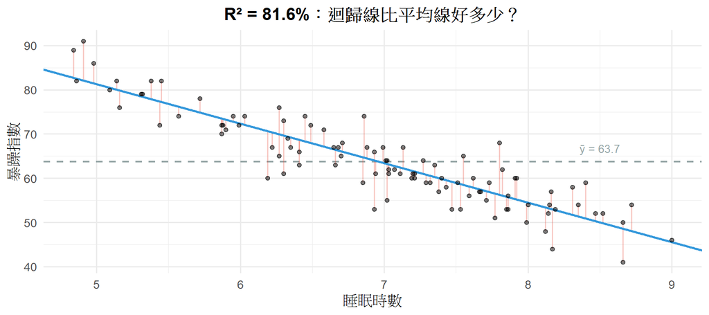

> 紅線（殘差）越短 → $R^2$ 越大 → 模型越**適配(fit)**

## jamovi 操作：Zhang et al. (2024) Study 2

Study 2 有三種教學分組（condition 0/1/2），各組都有前測（`Pre_sum`）與後測（`Post_sum`）。

**問題**：哪一組的前測最能預測後測？

## jamovi 操作：線性迴歸

**步驟**：

1. **Regression → Linear Regression**
2. 依變項（DV）放入 **Dependent Variable**
3. 自變項（IV）放入 **Covariates**
4. 調整 **Model Fit**（確認勾選 R²）
5. 調整 **Model Coefficients**（確認勾選 CI）
- 迴歸係數 *b* 的方向（正/負）與顯著指標(*p*)
- R² 的大小（解釋多少變異）

# Part 4：殘差診斷🧠👨‍💻

## 殘差 = 觀察值 - 預測值

$$e_i = Y_i - \hat{Y}_i$$

迴歸分析的**適用條件**：迴歸模型應該符合[四種適用條件](https://scgeeker.github.io/lsj-book-zh_tw/12-Correlation-and-linear-regression.html#sec-regression-assumptions)

- W7 檢測單一樣本資料符合常態性的方法，就是根據[資料之間的殘差](https://scgeeker.github.io/lsj-book-zh_tw/11-Comparing-two-means.html#sec-Checking-the-normality-of-a-sample)。
- 如果殘差診斷確定不符合適用條件，統計推論（p 值、信賴區間）可能不可靠
- 還有兩種殘差：**標準化殘差**、**學生化殘差**，參考[電子書12.10](https://scgeeker.github.io/lsj-book-zh_tw/12-Correlation-and-linear-regression.html#%E4%B8%89%E7%A8%AE%E6%AE%98%E5%B7%AE)
- 以下說明及示範唯一線性關係、常態性、變異同質性的適用條件診斷

## 判斷唯一線性關係

- 如何確認已經納入迴歸的自變項(e.g., dan.sleep, baby.sleep)，能夠充分預測應變項(e.g., dan.grumpiness)？
- 視覺化預測值($\hat{Y}_i$) vs. 觀察值($Y_i$)的線性關係是否貼合[對角線](https://scgeeker.github.io/lsj-book-zh_tw/12-Correlation-and-linear-regression.html#fig-fig12-17)
- 視覺化殘差($e_i$) vs. 預測值($\hat{Y}_i$)的線性關係是否貼合[水平線](https://scgeeker.github.io/lsj-book-zh_tw/12-Correlation-and-linear-regression.html#fig-fig12-18)

## 唯一線性關係診斷示範：Zhang et al. (2024) Study 2

- 使用清理後的”Study2_copy.xls”，了解所有參與者的”前測”能夠充分”後測”？
- 使用模組 `Regression` - `Linear Regression`
- 選單設定 Dependent Variable = `Post_sum`; Covariates = `Pre_sum`; “Save” 勾選`Predicted values`, `Residuals`
- 開啟Plots tab, 使用模組 `Scatter Plot` 兩次：(1) X-Axis = `Post_sum`, Y-Axis = `Predicted values`; (2) X-Axis = `Predicted values`, Y-Axis = `Residuals`
- 根據報表輸出的繪圖，`Post_sum` ~ `Pre_sum`是唯一有預測能力的迴歸線嗎?

## 殘差的常態性：視覺化診斷1

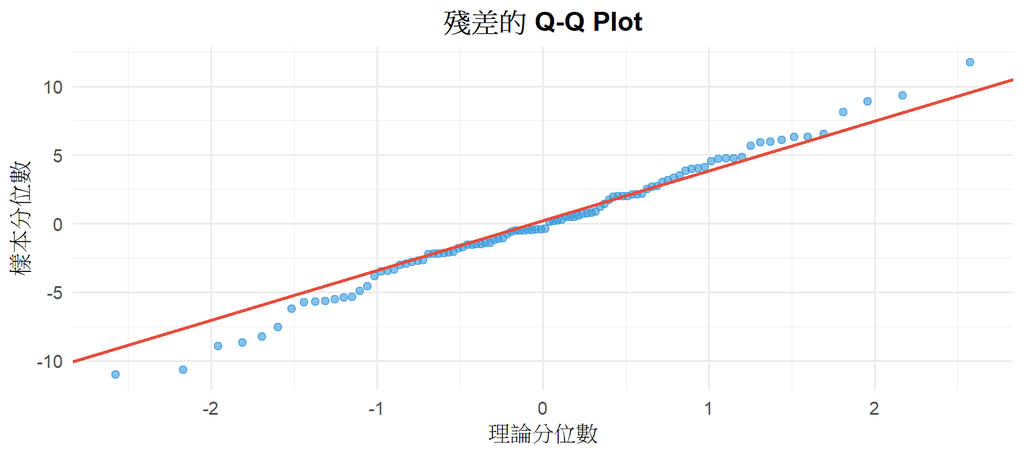

- 樣本分位數~理論分位數沿對角線排列 → 殘差近似常態 ✓

## 殘差的常態性：視覺化診斷2

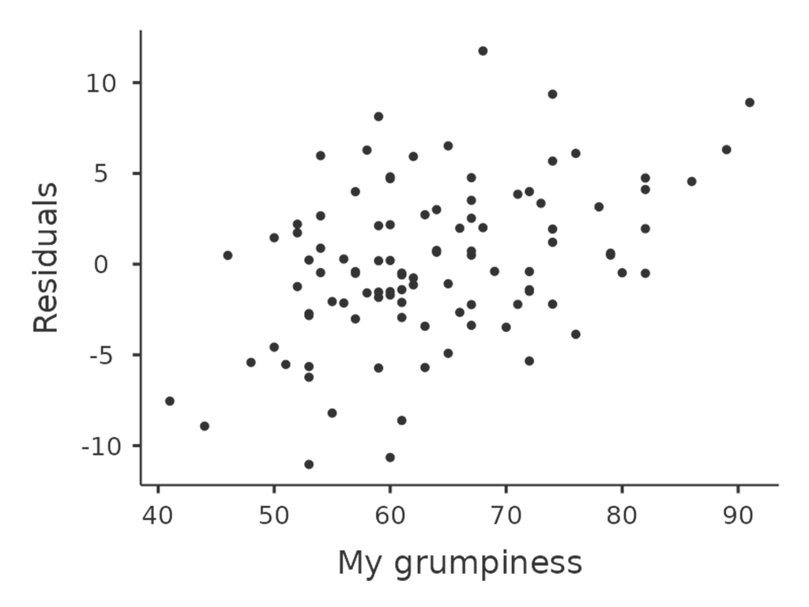

## 殘差的常態性診斷示範: Zhang et al. (2024) Study 2

- 使用模組 `Regression` - `Linear Regression`
- 選單設定 Dependent Variable = `Post_sum`; Covariates = `Pre_sum`; “Assumption Checks” 勾選`Normality test`, `Q-Q plot ofresiduals`, `Residual plots`
- 運用報表的表格及散佈圖，判斷分析資料的殘差是否符合常態假設？

## 殘差的變異同質性: 視覺化診斷

- 對應各預測值的殘差變異數(離散程度)，必須要相等。
- 以殘差絕對值的平方根 vs. 預測值散佈圖，判斷是否接近[水平線](https://davidfoxcroft.github.io/lsj-book/images/fig12-21.png)

# Part 5：迴歸係數的推論統計🧠👨‍💻

## 原始迴歸係數的推論統計

**問題**：樣本資料算出的迴歸係數 $b = -8.94$，是否為理論參數的有效估計？理論的迴歸係數會不會其實是 0（睡眠時間對暴躁程度毫無預測力）？

**假設**（理論參數迴歸係數 $b$）：

$$H_0:\ b = 0 \qquad H_1:\ b \neq
0$$

**檢定統計量**：估計值除以標準誤，逼近 $t$ 分佈

$$t = \frac{\hat{b}}{SE(\hat{b})}, \qquad
df = N - 2$$

> 簡單迴歸只有1個預測變項及1個應變項，自由度為 $N-2$。

## 對照 jamovi 報表：Model Coefficients

| 欄位 | 符號 | 意義 |
| --- | --- | --- |
| Estimate | $\hat{b}$ | 迴歸係數估計值（原始尺度） |
| SE | $SE(\hat{b})$ | 係數的標準誤（抽樣波動） |
| t | $t$ | $\hat{b} / SE(\hat{b})$ |
| p | — | 雙尾檢定的 $p$ 值 |
| Lower / Upper 95% CI | — | 母體係數的 95% 信賴區間 |

**parenthood 的 dan.sleep 係數**：

$$t = \frac{-8.94}{0.43} = -20.85,\quad df
= 98,\quad p < .001$$

- $p < .05$ → 拒絕 $H_0$：睡眠時數**確實**能預測暴躁指數
- 95% CI $= [-9.79,\ -8.09]$，**不包含 0** → 與 $p$ 值結論一致
- ⚠ 統計顯著 ≠ 有意義；必須看係數大小與研究脈絡

## 標準化迴歸係數的推論統計

**問題**：原始係數 $b$ 受**測量單位**影響。「每多睡 1 小時降 8.94 點」——若 X 改用「分鐘」，數字就完全不同，**不利於跨研究比較**。

**解決方法**：把原始資料轉成 $z$ 分數再做迴歸，得到**標準化係數 $\beta$**

$$\beta = b \times
\frac{\sigma_X}{\sigma_Y}$$

- $\beta$ 的單位是「標準差」：$X$ 每增加 **1 個標準差**，$\hat{Y}$ 改變 $\beta$ 個標準差
- 不受原始尺度影響，數值落在 $-1 \sim 1$ 之間，較易直觀解讀

## 標準化係數的解讀與報表

$$\beta = r \quad(\text{標準化係數} =
\text{Pearson } r)$$

**parenthood 實例**：

$$\beta = -8.94 \times \frac{1.02}{10.05}
= -0.903 \;=\; r\,(-0.903)$$

**jamovi 操作**：Model Coefficients → 勾選 **Standardized estimate**（可一併勾 Confidence interval），報表多出 $\beta$ 欄與其 95% CI。

- $\beta = -0.903$：睡眠長度每增加 1 個標準差，暴躁指數降低約 0.9 個標準差
- 與 Part 1 算出的 $r = -0.903$ **完全相同** → 驗證「簡單迴歸 $\beta = r$」
- 測量變項尺度相同時，原始係數 $b$ 較好解讀；$\beta$ 在需要跨研究比較時最有用

## jamovi 操作：Zhang et al. (2024) Study 2

**問題**：各組參與者前測成績（`Pre_sum`）能有效預測學習成效(`Post_sum`)？

**步驟**：

1. 使用Filter切換三種教學方法
2. **Regression → Linear Regression** → Dependent Variable置入 `Post_sum` 、 Covariates置入 `Pre_sum` ; “Model Coefficients”- Estimate 勾選 `Confidence interval`、Standardized Estimate 勾選 `Standardized estimate`, `Confidence interval`
3. 閱讀報表的 “Model Fit Measures”, “Model Coefficients”
4. 那一組的前測成績能有效預測學習成效？適用條件診斷的結果如何影響解讀？

# Part 6：本週作業

## 作業說明

**資料**：個人化 `W15_Regression_[學號].csv`

你的資料包含：

| 變項 | 類型 | 說明 |
| --- | --- | --- |
| `Study_Hours` | Continuous | 每週讀書時數 |
| `Total_Score` | Continuous | 總測驗分數 |

> ⚠ 建議流程：**先做適用條件診斷 → 再判斷如何解讀係數**。不符合適用條件，解讀迴歸係數與預測效力都要保持謹慎。

## 任務 1：建立模型並儲存診斷材料

**操作**：

1. **Regression → Linear Regression**
2. DV（依變項）：`Total_Score`；Covariates（自變項）：`Study_Hours`
3. **Save** 勾選 `Predicted values` 與 `Residuals`（資料表新增兩欄）
4. 設定計算變項 `SQR_Residuals`，算式 `SQRT(ABS(Residuals))`（供變異同質性診斷用）

> 先把係數放一邊 —— 先檢查模型能不能用。

## 任務 2：適用條件診斷（三項，先於係數解讀）

**(1) 線性關係**：Scatter Plot — X = `Predicted values`，Y = `Residuals`

- 點是否隨機散佈、貼近水平線（無系統性彎曲）？

**(2) 常態性**：Assumption Checks 勾 `Normality test`、`Q-Q plot of residuals`、`Residual plots`

- Q-Q 點是否沿對角線？Shapiro-Wilk 的 *p* 值是否 > .05？

**(3) 變異同質性**：Scatter Plot — X = `Predicted values`，Y = `SQR_Residuals`

- 離散程度是否大致均勻、貼近水平線？

> 在報告中**逐項判斷**三個適用條件是否成立。

## 任務 3：迴歸係數與推論統計

**操作**：Model Fit 勾 `R²`；Model Coefficients 勾 `Confidence interval`、`Standardized estimate`

1. 記錄：截距 $a$、迴歸係數 $b$、$R^2$
2. 係數推論：$t$、$p$、95% CI（CI 是否包含 0？）
3. 標準化迴歸係數 $\beta$，並驗證簡單迴歸 $\beta = r$
4. 寫出預測方程式：$\text{Total Score} = a + b \times \text{Study Hours}$

## 任務 4：APA 寫作

**格式範例**：簡單線性迴歸顯示，讀書時數能（顯著／不顯著）預測總分，*b* = ⋯, *t*(df) = ⋯, *p* = ⋯, *R*² = ⋯, β = ⋯。

> 依你的數據完成一段 APA 報告。

**反思問題**：

1. **Q1**：迴歸係數 *b* 的正負代表什麼？你的資料中 Study_Hours 與 Total_Score 的關係方向如何？
2. **Q2**：$R^2$ 代表什麼意義？你的模型解釋了多少比例的變異？
3. **Q3**：為什麼要先完成適用條件診斷，才能解讀迴歸係數？若其中一項適用條件不成立，會如何影響你對 $b$、$p$、CI 等統計資訊的解讀？

## 繳交要求

**檔案 1：學號_姓名_W15_Lab.omv**

- 線性迴歸分析（含 R²、95% CI、標準化估計）
- 已儲存 `Predicted values`、`Residuals`，並建立 `SQR_Residuals`
- 三項診斷圖：殘差 vs 預測值、Q-Q plot、SQR_Residuals vs 預測值

**檔案 2：學號_姓名_W15_Report.docx**

- 三項適用條件診斷結果與判斷
- 迴歸方程式、係數推論（t / p / CI）、標準化迴歸係數 β 解讀
- APA 報告
- 3 題反思問題

**繳交期限**：本日下課後，當天午夜12:00之前

# 小結與展望

## 本週核心概念

1. **迴歸方程式**：$Y = a + bX$，迴歸係數 $b$ = 預測變化量、截距 $a$ = $X=0$ 的預測值
2. **最小平方法**：讓殘差平方和最小的迴歸線
3. **$R^2$**：模型能解釋的變異比例
4. **適用條件診斷**：線性、常態性、變異同質性三項——**先診斷，再解讀係數**
5. **係數推論**：以 $t$ / $p$ / 95% CI 判斷迴歸係數是否顯著（CI 不含 0 → 顯著）
6. **標準化迴歸係數 $\beta$**：不受測量單位影響、可跨研究比較；簡單迴歸 $\beta = r$

## 課後資源

**電子書**：

- [第 12 章：線性迴歸](https://scgeeker.github.io/lsj-book-zh_tw/12-Correlation-and-linear-regression.html#sec-what-is-linear-model)

**關鍵術語對照**：

| 中文 | 英文 | 符號 |
| --- | --- | --- |
| 線性迴歸 | Linear Regression | — |
| 截距 | Intercept | $a$ |
| 迴歸係數 | Regression coefficient | $b$ |
| 殘差 | Residual | $e_i$ |
| 決定係數 | R-squared | $R^2$ |
| 標準化迴歸係數 | Standardized coefficient | $\beta$ |

## 下週W16預告

- 學期總複習
- 復盤這學期所學的統計原理，整理jamovi操作指南
- W15 LAB複評截止，統算平時LAB成績
- W17 期末LAB預告
- 無yt直播，於電腦教室進行複習演練及問題討論